# Workshop 6: An ODE to Probably Doing Enough (PDE)

*[CEGM1000 MUDE](http://mude.citg.tudelft.nl/): Week 1.6. For: 11 October, 2024.*

# Overview

This assignment contains two parts: treating non-linear ODEs and treating the diffusion equation (PDE).

## Section 1: Solving Non-linear ODEs

**Task 1**

The equation to solve using Newton-Rhapson is

$$ x^2=9 $$

**Task 1.1**

Formally Newton-Rhapson is implemented iterating the solution as follows: $$ z_{j+1} = z_{j} - g(z_j)/g'(z_j) $$ where $g(z_j) = 0$ and $z_j$ is a guess and $z_{j+1}$ is the improved guess.

As we do not care about retaining the values of every guess, it can be written in code as:

$$ x = x - g(x)/g'(x) $$

**Transform the equation $x^2=9$ to g(x) and write it below, together with g'(x).**

**Solution** $$ g(x) = x^2-9 \text{ and } g'(x) = 2*x $$

so $$ x = x - \frac{x^2-9}{2x} $$

**Task 1.2**

Implement your equations $g(x)$ and $g'(x)$ in the code below, as well as the Newton-Rhapson expression inside the loop. Test the code with the initial guess of $x=10$.

```python
import numpy as np

def g(x):
    return x**2 - 9

def g_der(x):
    return 2*x

x = .01
for j in range(100):
    x = x - g(x)/g_der(x)
    if np.abs(g(x)) < 1e-6:
        break


print("The solution found is ", x, " it took " ,j , " iterations to converge.")
```

```
The solution found is  3.000000000008298  it took  11  iterations to converge.
```

**Task 1.3**

The code is taking 100 iterations without stopping. **Add a condition to the code above to stop the loop once the solution is good enough**, i.e., when the solution is closer than $\epsilon = 1e-6$ to the exact solution. How many iterations does it take now to converge?

**Solution**

4 iterations

Write your answer here.

**Task 1.4**

Change the intial guess to $x=0.01$, which is closer to the exact solution than the initial guess in the previous task. How many iterations does it take to converge? Explain the difference.

**Solution**

It takes 11 iterations, 7 more than in the previous case despite the guess being closer to the solution. This is because at that location the derivative is close to 0 and if first goes far away from the solution.

Write your answer here.

**Task 2**

Solve the following ODE using Explicit and Implicit Euler.

$$ \frac{dy}{dt} = \sin(y^3)+\sin(t) $$

with initial value $y(t=0) = 1$

**Task 2.1**

Write in paper the Explicit and Implicit Euler schemes of the equation above.

**Solution**

The Explicit Euler Scheme: $$ y_{i+1} = y_{i} + \Delta t (\sin(y_i^3)+\sin(t_i)) $$

The Implicit Euler scheme: $$ y_{i+1} = y_{i} + \Delta t (\sin(y_{i+1}^3)+\sin(t_{i+1})) $$

Write your answer here.

**Task 2.2**

Just as before, Newton-Rhapson must be implemented following: $$ z_{j+1} = z_{j} - g(z_j)/g'(z_j) $$ where $g(z_j) = 0$ and $z_j$ is a guess and $z_{j+1}$ is the improved guess.

Which term from your Implicit Euler scheme represents $z$? **Transform your Implicit Euler scheme into g(*) and write it below, together with g'(*).**

**Solution** $$ g(y_{i+1}) = y_{i+1}-y_{i} - \Delta t (\sin(y_{i+1}^3)+\sin(t_{i+1})) $$

and

$$ g'(y_{i+1}) = 1 - \Delta t * 3y_{i+1}^2\cos(y_{i+1}^3) $$

Write your answer here.

**Task 2.3**

Implement the Explicit Euler and Implicit Euler schemes by filling the lines of code below:

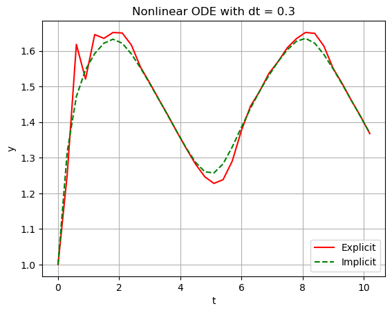

```python
import matplotlib.pyplot as plt


def g(y_iplus1,y_i, t_iplus1):
    return y_iplus1-y_i-dt*(np.sin(y_iplus1**3)+np.sin(t_iplus1))

def g_der(y_iplus1):
    return 1-3*dt*y**2*np.cos(y_iplus1**3)


# Define parameters:
dt = .3
t_end = 10
t = np.arange(0,t_end+dt,dt)

y_EE = np.zeros(t.shape)
y_IE = np.zeros(t.shape)

# Define Initial Conditions
y_EE[0] = 1
y_IE[0] = 1

# Perform time-integration
newtonFailed = 0
for i in range(0, len(t)-1):

    # Forward Euler:
    y_EE[i+1] = y_EE[i] + dt*(np.sin(y_EE[i]**3)+np.sin(t[i]))

    # Backward Euler:
    y_IE[i+1] = y_IE[i] # initial guess
    for j in range(200):
        y_IE[i+1] = y_IE[i+1] - g(y_IE[i+1],y_IE[i],t[i+1])/g_der(y_IE[i+1])
        if np.abs(g(y_IE[i+1],y_IE[i],t[i+1])) < 1e-6:
            break

    if j >= 199:
        newtonFailed = 1


# Plotting the solution
plt.plot(t, y_EE, 'r', t, y_IE, 'g--')
if newtonFailed:
    plt.title('Nonlinear ODE with dt = ' + str(dt) + ' \nImplicit Euler did not converge')
else:
    plt.title('Nonlinear ODE with dt = ' + str(dt))

plt.xlabel('t')
plt.ylabel('y')
plt.gca().legend(('Explicit','Implicit'))
plt.grid()
plt.show()
```

## Section 2: Diffusion Equation in 1D

The 1-D diffusion equation reads $$\frac{\partial u}{\partial t}=v\frac{\partial^2 u}{\partial x^2}$$

where $u$ is a continuous function in space and time, $v$ is a constant and often referred to as the **diffusivity coefficient**, giving rise to the name 'diffusion equation'. This is a Partial Differential Equation which independent variable, $u$, varies on space and time. This equation is virtually present across all fields of civil engineering and science. Here, we use it to represent the temperature on a rod (see the sketch below).

Unlike the problem of Wednesday, here there is no exchange of heat with the ambient and the temperature evolves in time. The temperature initially is uniform along the rod, equal to $7°C$. Then it is heated at both ends. .

[figure not shown]

The problem is schematized as a one-dimensional $30cm$ steel rod of with a diffusivity coefficient of $4 mm^2/s$. Run the simulation for $10,000 s$ to see the progression of the temperature through the model. Start with $200$ steps.

```python
import numpy as np
import matplotlib.pyplot as plt
```

**Task 3**

Solve the diffusion equation using Central Differences in space and Forward Differences in time. You will do this step by step (subtasks).

For convenience we write here the diffusion equation with the temperature variable:

$$ \frac{\partial T}{\partial t}=v\frac{\partial^2 T}{\partial x^2} $$

**Task 3.1:**

How many constraints are needed in the 1D diffusion equation to have a well-posed problem?

**Solution**

One initial condition and two boundary conditions are needed.

Write your answer here.

**Task 3.2:**

Draw a grid of 6 points with subindexes. Although your actual grid will be much larger, 6 points are enough to visualize the procedure. The initial condition states that the temperature of the rod is $7^o$ C. Does that mean that one single point of your grid is initialized or all of them?

**Solution**

Drawing of the grid.

Write your answer here.

**Task 3.3:**

Now, the differential equation needs to be expressed in algebraic form using central differences in space and forward differences in time. **Start by just transforming the PDE into a first-order ODE by ONLY applying Central Differences to the spatial derivative term.**

**Solution** $$ \frac{\partial T}{\partial t}\bigg|_i = \nu \frac{T_{i+1}-2T_i+T_{i-1}}{\Delta x^2} $$

Write your answer here.

**Task 3.4:**

Before applying Forward Differences in time to the equation. It is needed to add a superscript to the notation that indicates the time step: $T^j_i$. So, $i$ indicates the spatial location and $j$ the time location. For example, $T^0_2$ indicates the temperature at the node $i=2$ and at the initial moment $j=0 (t=0)$. Furthermore, to express in a general form a node of over the next time step, you can express $T^{j+1}_i$.

**Apply Forward Differences to the equation to obtain an algebraic expression.**

**Solution** $$ T^{j+1}_{i} = T^j_i + \frac{\nu \Delta t}{\Delta x^2} \left(T^j_{i+1}-2T^j_i+T^j_{i-1}\right) $$

Write your answer here.

**NOTE**

If you have doubts of your solution, ask a staff member! It is important to be in the right track!!

**NOTE TO TEACHERS** EVERYTHING BELOW THIS POINT IS VERY MUCH IN DRAFT. THE GENERAL SCOPE WILL BE AS FOLLOWS:

**Task 3.5:**

Finally, the coding part! Let's start with defining the parameters and creating the grid. **Fill in the missing parts of the code.**

```python
# T_left =
# T_right =
# T_initial =
# length =
# n_point =
# nu =
# dt =
# nt =

# Solution
T_left = 38        # Temperature at the left
T_right = 25       # Temperature at the right
T_initial = 7      # Initial temperature of the bar
length = 300       # Length of the bar in mm
n_point = 15       # Number of points
nu = 4             # Constant value nu mm^2/s (representative value for steel)
dt = 50            # Time increment in seconds
nt = 200           # Number of time increments

dx = length/(n_point-1)
x = np.linspace(0,length,n_point)
```

Let's initialise the system with the initial and boundary conditions. Say $t_0 =0$.

**Task 3.6:**

Define the initial conditions and the boundary conditions. **Fill in the missing parts of the code.**

```python
# Initialise empty solution array "us"
us = np.zeros((nt+1,n_point))

# Initialise initial conditions into the solution array t=0
# us[0] =
# Solution:
us[0] = T_initial

# Initialise boundary conditions into the solution array at t=0
# Remember that the first term is the left boundary and the last term is the right boundary.
# us[0][0] =
# us[0][-1] =
# Solution:
us[0][0] = T_left
us[0][-1] = T_right
```

The finite difference operation will involve using an array that contains $u$ at every point in the array `x` (code), `dt`, `dx` and `nu` to return an array that contains $u$ at every point in the array `x` at the **next time step**.

But what about the boundary points? These will remain the same as the boundaries are held at a constant temperature. Hence, for each array pertaining to $u$, the first and the last values should correspond to the boundary temperatures, before the array is used an a input for the finite difference operation. The rest of the terms can be consded as per the equation in Step 3. In short, while advancing in time, from `0` to `nt*dt`, the first and lasts elements of the array $u$ will not be advanced in time but in fact, be assigned the boundary values of temperature.

So if the $u$ array corresponding to the first time-step has the correct boundary values, the finite difference operation need only copy these values to their locations in every successive array in time. This can be done as an if and else statement.

```python
def fdm_step(u, dx, dt, nu):

    u_new = np.zeros(len(u))

    for i in range(len(u)):

        if i == 0 or i == len(u)-1: # Exclue fixed boundary point at ends

            u_new[i] = u[i]
        else:
            u_new[i] = u[i] + nu*dt*(u[i+1] - 2*u[i] + u[i-1])/(dx**2)

    return u_new
```

**Task 1.4:**

You now have the finite difference operation and initial arrays. Now write a single line of code to loop over all time steps to obtain the solution at `dt*nt`.

```python
for i in range(nt):
    us[i+1] = fdm_step(us[i],dx, dt, nu)
```

Visualization of the temporal evolution.

```python
def FDM_plot(x, u, step):
    fig = plt.figure()
    ax = plt.axes(xlim=(0, 300), ylim=(0, 40))
    ax.plot(x, u[step])
    plt.xlabel('x')
    plt.ylabel('u')
    plt.show()

play = widgets.Play(min=0, max=nt-1, step=1, value=0, interval=100, disabled=False)
slider = widgets.IntSlider(min=0, max=nt-1, step=1, value=0)
widgets.jslink((play, 'value'), (slider, 'value'))

interact(FDM_plot,
    x=fixed(x),
    u=fixed(us),
    step = (play))

widgets.HBox([slider])
```

[output not shown]

**Note:** Depending on your choice of time step, you may have noticed that your notebook did not converge. This would have looked like a log of oscillations (jagged up-and-down lines) that appear during the animation, which then increase out of control. This happens because the numerical approach used here is conditionally stable; large time steps do not work well. This has to do with the high value of the diffusivity parameter.

**Task 1.5:**

Explain what the animation above shows? Does the temperature reach a steady-state? What does that mean for heat flow?

Record your answer in the following markdown cell.

**Solution**

Animated plot above shows how the ends of the rod at temperatures of $38^oC$ and $25^oC$ but $7^oC$ elsewhere. As the animation begins, you can notice how the temperature increases through the rod and eventually becomes a constant gradient across the length of the rod, indicating a steady-state.

## Task 2: Altering the right boundary

Say the right-end of the bar is heated with the cyclic function: $$ u(L,t)=25+10\sin\left(\frac{2\pi t}{T}\right)$$

**Task 2.1:**

Based on the initialization of the problem as described in Task 1.4, can you set up the initial and boundary conditions for this situation? (you only need to change one condition).

```python
t = 0
T = 6000

nt = 600
us = np.zeros((nt+1,n_point))

# us[0] =
# Solution:
us[0] = T_initial

# us[0][-1] =
# Solution:
us[0][0] = T_left
us[0][-1] = 25 + 10*np.sin(2*np.pi*t/T)
```

To pass on the value of the time-dependent boundary condition `T_Right` to the iteration loop, you must copy the value of `us` (the solution) to another array, modify the boundary condition on the right (which element of the array will that be?) and pass the modified array to the solution function `fdm_step`.

You can use the following code for dynamic plotting:

```python
play = widgets.Play(min=0, max=nt-1, step=1, value=0, interval=100, disabled=False)
slider = widgets.IntSlider(min=0, max=nt-1, step=1, value=0)
widgets.jslink((play, 'value'), (slider, 'value'))

interact(FDM_plot,
    x=fixed(x),
    u=fixed(us),
    step=play)

widgets.HBox([slider])

for i in range(nt):
    umod = us[i].copy()
    umod[-1] = 25 + 10*np.sin(2*np.pi*t/T)
    us[i+1] = fdm_step(umod, dx, dt, nu)
    # Update time
    t += dt
```

**Task 2.2:**

Why is the right boundary dealt with differently in the code than previously? What is different in this version compared to the first?

Record your answer in the following markdown cell.

**Solution**

Replacing the right-hand boundary with a sinusoidal function means that the temperature at the right end of the rod now fluctuates and this then affects the temperature as it diffuses through the rod.

**End of notebook.**

© Copyright 2023 [MUDE Teaching Team](https://studiegids.tudelft.nl/a101_displayCourse.do?course_id=65595) TU Delft. This work is licensed under a [Creative Commons Attribution-NonCommercial-ShareAlike 4.0 International License](http://creativecommons.org/licenses/by-nc-sa/4.0/).